# Homework Week 5: Correlation & Regression

Mickayla Johnston

10/12/2020

##### Libraries

```r
library(dplyr)
library(ggplot2)
```

##### Load data

```r
getwd()
```

```
## [1] "/Users/mickaylajohnston/Documents/Graduate_School/GradRStats/bio607/FA2020/homework/markdown"
```

```r
language <- read.csv("../data/week_5/chap16q15LanguageGreyMatter.csv")
liver <- read.csv("../data/week_5/chap16q19LiverPreparation.csv")
nutrients <- read.csv("../data/week_5/chap17q19GrasslandNutrientsPlantSpecies.csv")
beetles <- read.csv("../data/week_5/chap17q25BeetleWingsAndHorns.csv")
nuclear <- read.csv("../data/week_5/chap17q30NuclearTeeth.csv")
```

##### See what’s there

```r
str(language)
```

```
## 'data.frame':    22 obs. of  2 variables:
##  $ proficiency: num  0.26 0.44 0.89 1.26 1.69 1.97 1.98 2.24 2.24 2.58 ...
##  $ greymatter : num  -0.07 -0.08 -0.008 -0.009 -0.023 -0.009 -0.036 -0.029 -0.008 -0.023 ...
```

```r
skimr::skim(language)
```

Data summary

| Name | language |
| --- | --- |
| Number of rows | 22 |
| Number of columns | 2 |
| _______________________ |  |
| Column type frequency: |  |
| numeric | 2 |
| ________________________ |  |
| Group variables | None |

**Variable type: numeric**

| skim_variable | n_missing | complete_rate | mean | sd | p0 | p25 | p50 | p75 | p100 | hist |
| --- | --- | --- | --- | --- | --- | --- | --- | --- | --- | --- |
| proficiency | 0 | 1 | 2.4 | 1.00 | 0.26 | 1.97 | 2.52 | 3.16 | 3.85 | ▃▂▅▇▇ |
| greymatter | 0 | 1 | 0.0 | 0.04 | -0.08 | -0.02 | -0.01 | 0.02 | 0.06 | ▂▂▇▅▃ |

```r
summary(language)
```

```
##   proficiency      greymatter
##  Min.   :0.260   Min.   :-0.0800000
##  1st Qu.:1.972   1st Qu.:-0.0195000
##  Median :2.525   Median :-0.0070000
##  Mean   :2.400   Mean   : 0.0004091
##  3rd Qu.:3.163   3rd Qu.: 0.0227500
##  Max.   :3.850   Max.   : 0.0620000
```

#### 1. Correlation: W&S ch.16

##### 1a. Display the association between the 2 variables in a scatterplot

```r
language_plot <- ggplot(data = language,
                    mapping = aes(x = proficiency, y = greymatter)) +
  geom_point()
```

###### View it

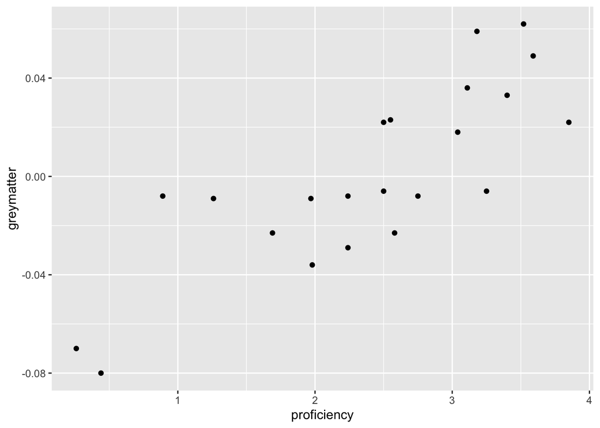

```r
language_plot
```

##### 1b. Calculate the correlation between language proficiency and gray matter density

```r
cor(language)
```

```
##             proficiency greymatter
## proficiency   1.0000000  0.8183134
## greymatter    0.8183134  1.0000000
```

###### The correlation is 0.8183134

##### 1c. Test the null hypothesis of zero correlation

###### The null hypothesis is that there is no correlation between language proficiency and gray matter density

###### The alternative hypothesis is that there is a correlation between language proficinecy and gray matter density

##### Fit model

```r
language_mod <- lm(greymatter ~ proficiency,
                   data = language)
```

##### View model

```r
summary(language_mod)
```

```
##
## Call:
## lm(formula = greymatter ~ proficiency, data = language)
##
## Residuals:
##       Min        1Q    Median        3Q       Max
## -0.032123 -0.020623 -0.001865  0.017059  0.037232
##
## Coefficients:
##              Estimate Std. Error t value Pr(>|t|)
## (Intercept) -0.072142   0.012309  -5.861 9.84e-06 ***
## proficiency  0.030235   0.004749   6.367 3.26e-06 ***
## ---
## Signif. codes:  0 '***' 0.001 '**' 0.01 '*' 0.05 '.' 0.1 ' ' 1
##
## Residual standard error: 0.02183 on 20 degrees of freedom
## Multiple R-squared:  0.6696, Adjusted R-squared:  0.6531
## F-statistic: 40.54 on 1 and 20 DF,  p-value: 3.264e-06
```

###### The t-value is 6.367, and the p-value of 3.264e-06 is less than 0.05, so we can reject the null hypothesis of zero correlation.

##### 1d. What are your assumptions?

###### Assumptions of correlation testing:

```
 1. The observations are from a random sample
 2. Each observation is independent
 3. x & y are from a bivariate normal distribution
```

##### 1e. Does your scatter plot support these assumptions?

###### According to W&S (ch.16), a scatter plot of data from a bivariate normal distribution should show that the x & y relationship is linear, and the cloud of points in the scatter plot should have a circular / elliptical shape. Although there aren’t many points in the scatterplot (see above), it does seem to support these assumptions. However, it should be pointed out that there is a gap in the “elliptical shape” in the scatter plot, from the two points in the bottom left corner (possible outliers?).

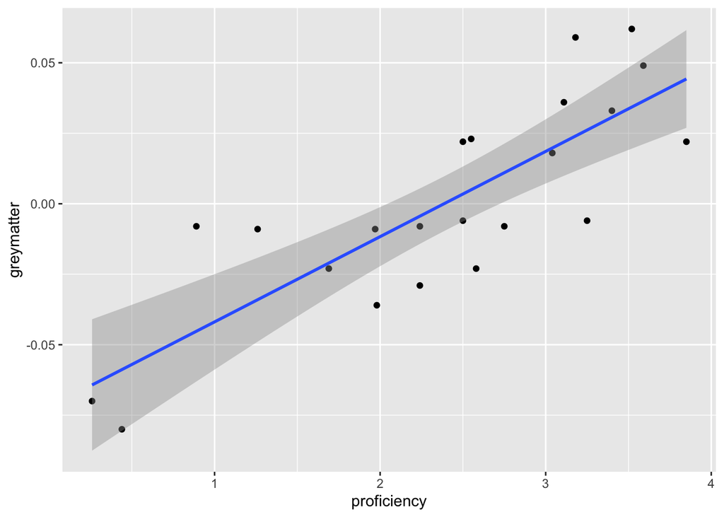

```r
language_plot + stat_smooth(method = lm)
```

##### 1f. Do the results indicate that language proficiency effects graymatter area in the brain? Why or why not?

[output not shown]

#### 2. Rat Liver Data:

```r
str(liver)
```

```
## 'data.frame':    5 obs. of  2 variables:
##  $ concentration  : num  2.8 5.8 12 23.9 47.8
##  $ unboundFraction: num  0.63 0.44 0.31 0.19 0.13
```

##### 2a. Calculate the correlation between the two variables

```r
cor(liver)
```

```
##                 concentration unboundFraction
## concentration       1.0000000      -0.8563765
## unboundFraction    -0.8563765       1.0000000
```

###### The correlation is -0.8563765

##### 2b. Plot the relationship

```r
liver_plot <- ggplot(data = liver,
mapping = aes(x = concentration, y = unboundFraction)) +
  geom_point()
```

###### View it

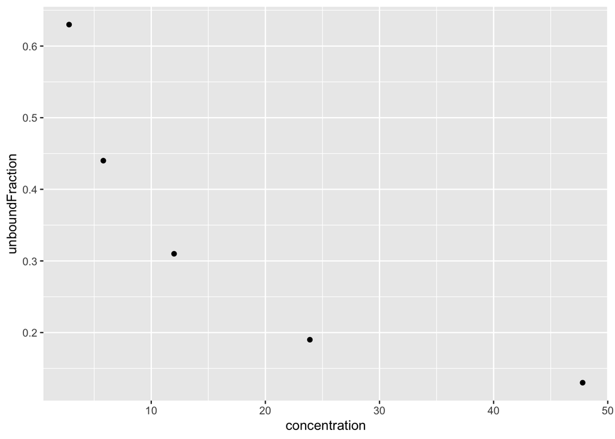

```r
liver_plot
```

##### 2c. The relationship appears to be maximlly strong, yet the correlation coefficient is not near the maximum possible value. Why not?

###### The plot appears to show a curve in the data– so, the relationship is non-linear.

##### 2d. What steps would you take to ensure the assumptions of the correlation analysis were met?

###### Make sure that the sampling procedure involves true random sampling: every individual in the population has an equal chance of being sampled, and the sampling of each individual is independent from one another. In the case of this experiment, one should ensure rats are chosen at random (ensuring the criteria listed above are met). Each rat can be numbered, and then using a random number generator, rats can be selected for the experiment. Also, as noted in W&S, we can log-transform the data to make the shape of the relationship linear, so that an lm can be used. Or, another method such as Spearman’s r can be used.

#### 3. Correlation SE

```r
happy_cats <- data.frame(cats = c(-0.30 , 0.42, 0.85, -0.45 , 0.22, -0.12   , 1.46, -0.79, 0.40, -0.07),
                         happiness_score = c(-0.57, -0.10, -0.04, -0.29, 0.42, -0.92, 0.99, -0.62, 1.14, 0.33))

happy_cats
```

```
##     cats happiness_score
## 1  -0.30           -0.57
## 2   0.42           -0.10
## 3   0.85           -0.04
## 4  -0.45           -0.29
## 5   0.22            0.42
## 6  -0.12           -0.92
## 7   1.46            0.99
## 8  -0.79           -0.62
## 9   0.40            1.14
## 10 -0.07            0.33
```

##### 3a. Are these two variables correlated? What is the output of cor() here. What does a test show you?

```r
cor(happy_cats)
```

```
##                      cats happiness_score
## cats            1.0000000       0.6758738
## happiness_score 0.6758738       1.0000000
```

```r
#                 cats          happiness_score
# cats            1.0000000       0.6758738
# happiness_score 0.6758738       1.0000000
```

###### The output shows that the r value is 0.6758738, which doesn’t indicate a very strong correlation. The r value tells us the strength / degree of association between the variables “cats” and “happiness score”

##### 3b. What is the SE of the correlation based on the info from cor.test()

```r
cor.test(happy_cats$cats, happy_cats$happiness_score)
```

```
##
##  Pearson's product-moment correlation
##
## data:  happy_cats$cats and happy_cats$happiness_score
## t = 2.5938, df = 8, p-value = 0.03193
## alternative hypothesis: true correlation is not equal to 0
## 95 percent confidence interval:
##  0.08050709 0.91578829
## sample estimates:
##       cor
## 0.6758738
```

###### Equation = squareroot of (1-r^2)/ (n-2)

r^2

```r
0.6758738^2
```

```
## [1] 0.4568054
```

0.4568054

```r
1 - 0.4568054
```

```
## [1] 0.5431946
```

= 0.5431946

n-2

```r
nrow(happy_cats)
```

```
## [1] 10
```

10-2 = 8

```r
sqrt((0.5431946) / 8)
```

```
## [1] 0.260575
```

###### ANSWER: 0.260575

##### 3c. Now, what is the SE via simulation? To do this, you’ll need to use cor() and get the relevant parameter from the output (remember - you get a matrix back, so, what’s the right index!), replicate(), and sample() or dplyr::sample_n() with replace=TRUE to get, let’s say, 1000 correlations. How does this compare to your value above?

###### Test cor()[1,2]

```r
cor(happy_cats)[1,2]
```

```
## [1] 0.6758738
```

###### Run sims

```r
cat_sim <-
  # replicate
  replicate(1000,
            # cor
            cor(
              # sample & correct index [1,2]
              sample(happy_cats,
                     size = length(happy_cats),
                     replace=TRUE))[1,2])
```

###### Get SE

```r
sd(cat_sim)
```

```
## [1] 0.1620806
```

#### 4. W&S Ch.17

```r
str(nutrients)
```

```
## 'data.frame':    10 obs. of  2 variables:
##  $ nutrients: int  0 0 0 1 2 3 1 3 4 4
##  $ species  : int  36 36 32 34 33 30 20 23 21 16
```

##### 4a. Draw a scatter plot. What is the x variable and what is the y?

###### The x variable is nutrients, and the y is species

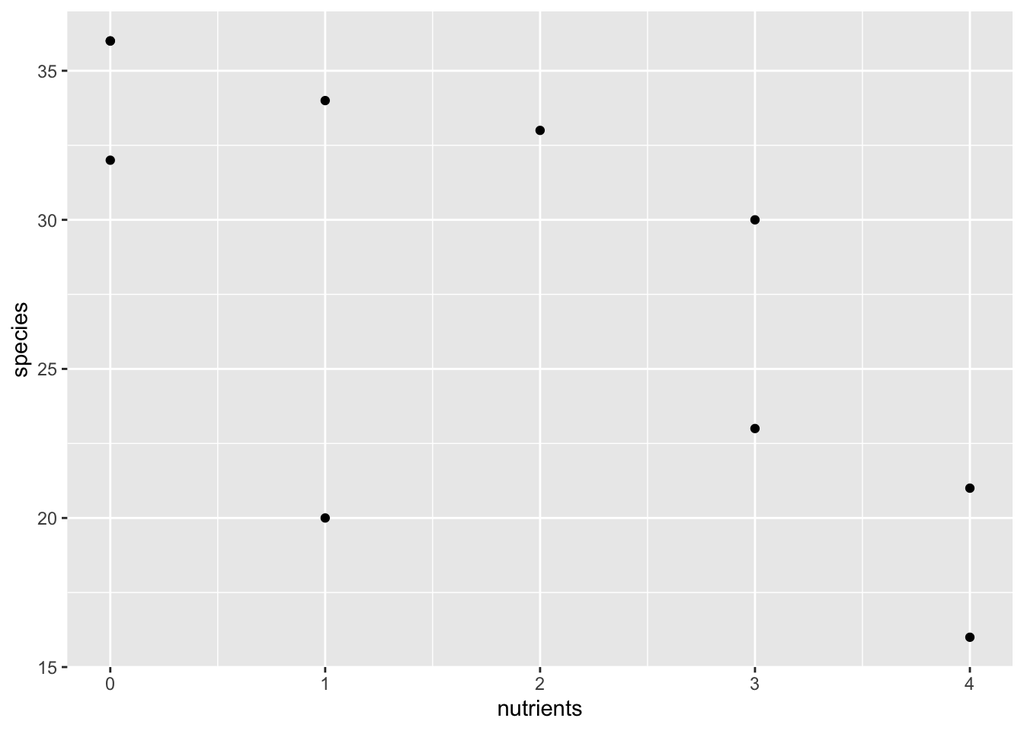

```r
nutrients_plot <- ggplot(data = nutrients,
                         mapping = aes(x = nutrients, y = species)) +
  geom_point()

# view it
nutrients_plot
```

##### 4b. What is the rate of change in the number of plant species supported per nutrient type added? Provide the SE for your estimate

###### Fit model

```r
nutrients_mod <- lm(species ~ nutrients, data = nutrients)

# View it
summary(nutrients_mod)
```

```
##
## Call:
## lm(formula = species ~ nutrients, data = nutrients)
##
## Residuals:
##     Min      1Q  Median      3Q     Max
## -10.771  -1.856   1.068   2.894   5.907
##
## Coefficients:
##             Estimate Std. Error t value Pr(>|t|)
## (Intercept)   34.110      2.599   13.12 1.08e-06 ***
## nutrients     -3.339      1.098   -3.04   0.0161 *
## ---
## Signif. codes:  0 '***' 0.001 '**' 0.01 '*' 0.05 '.' 0.1 ' ' 1
##
## Residual standard error: 5.336 on 8 degrees of freedom
## Multiple R-squared:  0.536,  Adjusted R-squared:  0.478
## F-statistic: 9.241 on 1 and 8 DF,  p-value: 0.01607
```

###### The slope is -3.339. This means that for every 1 nutrient added, ~3.3 species are lost.

###### The SE is 1.098

##### 4c. Add the least-squares regression line to your scatter plot. What fraction of the variation in the number of plant species is explained by the number of nutrients added?

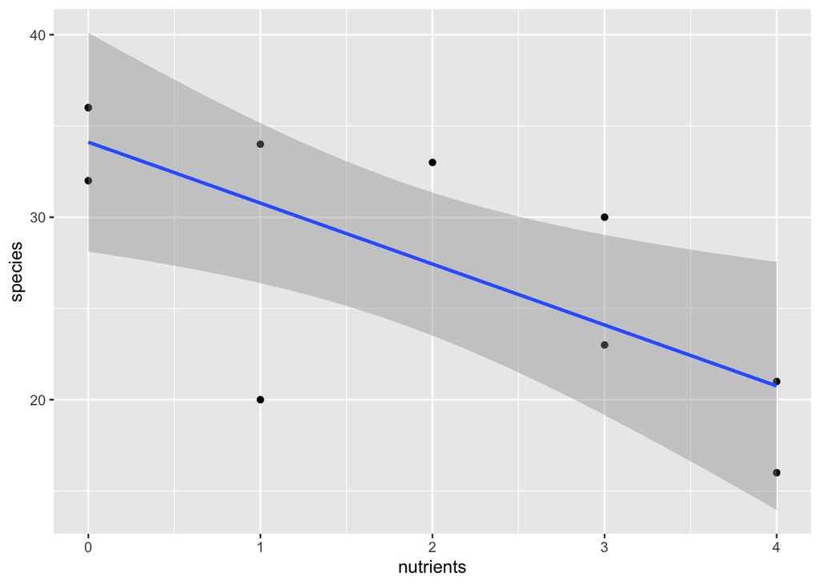

```r
nutrients_plot + stat_smooth(method = lm)
```

###### Answer: 0.536 of the variation in the number of plant species is explained by the number of nutrients added (The R2 value from the summary output)

##### 4d. Test the null hypothesis of no treatment effect on the number of plant species

###### t-value = -3.04

###### p-value = 0.0161, which means we can reject the null hypothesis that the addition of nutrients has no effect on the number of species

#### 5. W&S Chapter 17-25

##### 5a. Use these results to calculate the residuals

###### Fit a model

```r
beetle_mod <- lm(wingMass ~ hornSize, data = beetles)

# view model
beetle_mod
```

```
##
## Call:
## lm(formula = wingMass ~ hornSize, data = beetles)
##
## Coefficients:
## (Intercept)     hornSize
##      -0.129     -132.617
```

###### Calculate resids

```r
beetle_resids <- residuals(beetle_mod)

# View it
beetle_resids
```

```
##           1           2           3           4           5           6
## -32.8573453 -11.0942627 -16.1512536 -13.6164867  -1.3985636  22.4709703
##           7           8           9          10          11          12
##   9.1878142   4.7792124   4.4921151   2.1573482  -0.1405014  -3.0362005
##          13          14          15          16          17          18
##   3.6089591  11.6089591  19.4724013  20.4724013   2.7236525  -6.3351291
##          19
## -16.3440907
```

```r
# Make it a df
beetle_resids_df <- as.data.frame(beetle_resids)

# Combine it with beetles data
resid_plot_df <- cbind(beetles, beetle_resids_df)

# View it
resid_plot_df
```

```
##    hornSize wingMass beetle_resids
## 1     0.074    -42.8   -32.8573453
## 2     0.079    -21.7   -11.0942627
## 3     0.019    -18.8   -16.1512536
## 4     0.017    -16.0   -13.6164867
## 5     0.085    -12.8    -1.3985636
## 6     0.081     11.6    22.4709703
## 7     0.011      7.6     9.1878142
## 8     0.023      1.6     4.7792124
## 9     0.005      3.7     4.4921151
## 10    0.007      1.1     2.1573482
## 11    0.004     -0.8    -0.1405014
## 12   -0.002     -2.9    -3.0362005
## 13   -0.065     12.1     3.6089591
## 14   -0.065     20.1    11.6089591
## 15   -0.014     21.2    19.4724013
## 16   -0.014     22.2    20.4724013
## 17   -0.132     20.1     2.7236525
## 18   -0.143     12.5    -6.3351291
## 19   -0.177      7.0   -16.3440907
```

##### 5b. Use your results from part a to calculate a residuals plot

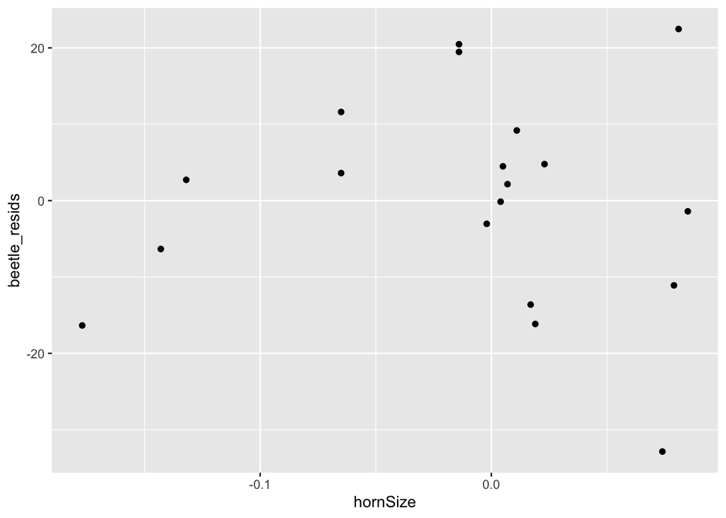

```r
ggplot(data = resid_plot_df,
       mapping = aes(x = hornSize,
                     y = beetle_resids)) +
  geom_point()
```

##### 5d. In light of your conclusions from part c, what steps should be taken?

###### Other assumption tests can be explored (next question), and/or the data can be transformed and the model refit. A log transformation can get rid of the negative values in the data.

##### 5e. Do any other diagnostics misbehave?

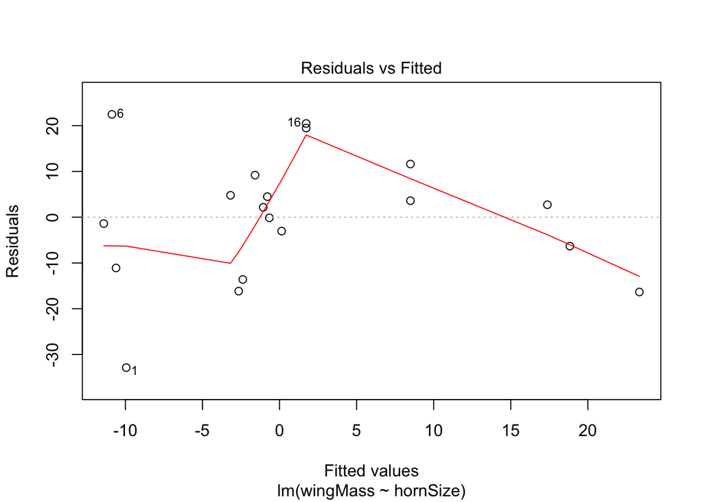

```r
plot(beetle_mod, which = 1) # RESIDUALS VS. FITTED
```

###### The residuals vs. fitted plot doesn’t seem to be too bad, though the points do sort of fall along the horizontal line.These points should be random- there should be no pattern, thus indicating the assumption of equal variance of errors is met.

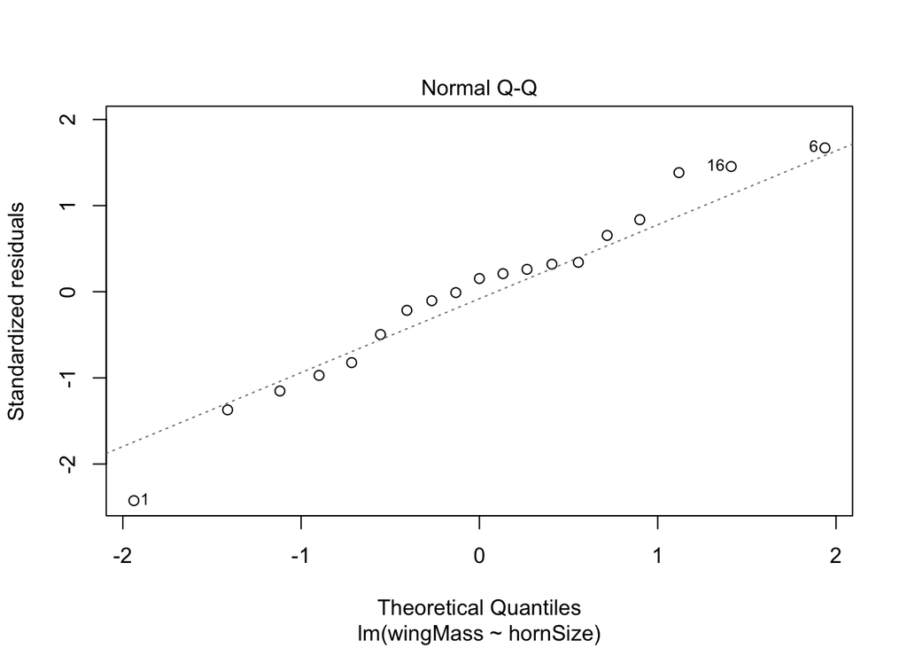

```r
plot(beetle_mod, which = 2) # Q-Q PLOT
```

###### The Q-Q plot seems ok as well- the points fall along the line for the most part, thus indicating the normality of errors assumption is met.

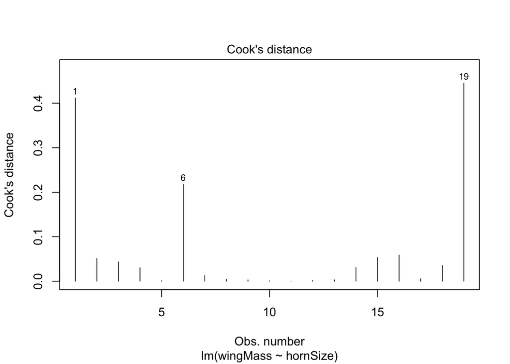

```r
plot(beetle_mod, which = 4)
```

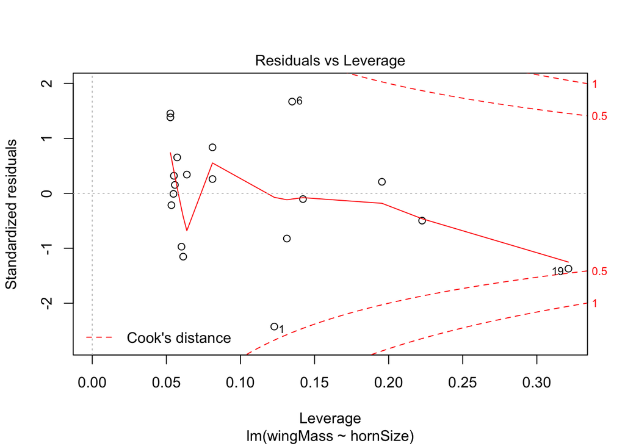

```r
plot(beetle_mod, which = 5) # RESIDUALS VS LEVERAGE
```

#### 6. W&S Ch. 17-30

##### 6d. Using `predict()` and `geom_ribbon()` in ggplot2, reproduce the above plot showing data, fit, fit interval, and prediction interval.

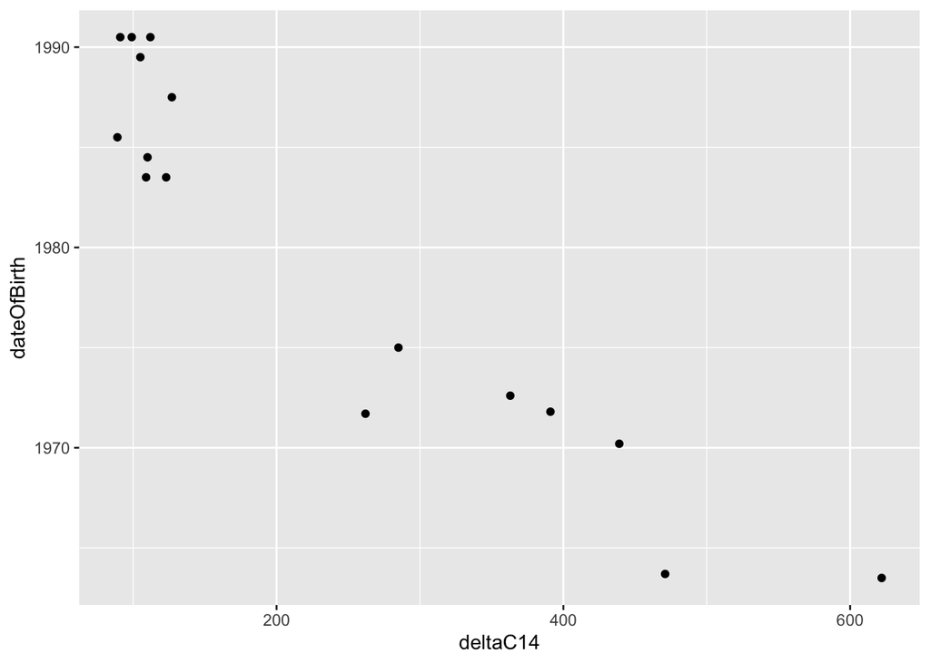

```r
# Fit this model
nuclear_mod <- lm(dateOfBirth ~ deltaC14, data = nuclear)

# Regular fit plot

nuclear_plot <- ggplot(data = nuclear,
                       mapping = aes(x = deltaC14,
                                     y = dateOfBirth)) +
  geom_point()

# View it
nuclear_plot
```

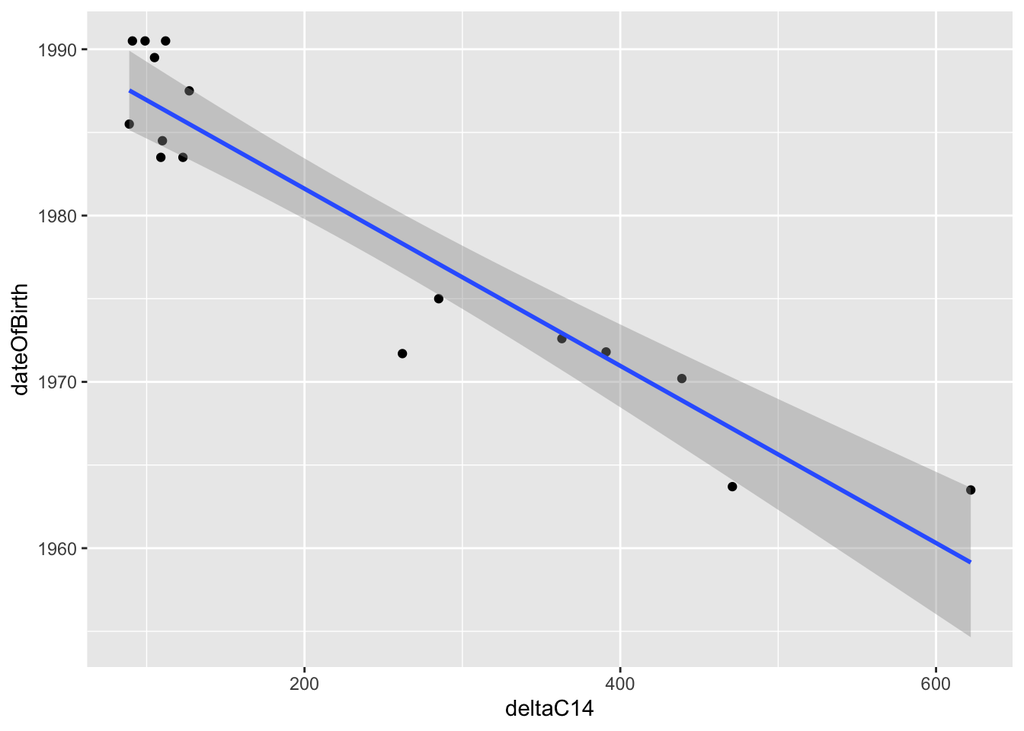

```r
# Add regression line
nuclear_plot + stat_smooth(method = lm)
```

```r
# CI values
fit_nuclear <- predict.lm(nuclear_mod,
                        interval = "confidence") %>%
  # turned it into a df or tibble
  as_tibble() %>%
  # renamed columns for clarity
  rename(lwr_ci = lwr,
         upr_ci = upr)

# combine them
nuclear <- cbind(nuclear, fit_nuclear)

# Predicted values
predict_nuclear <- predict(nuclear_mod,
                         interval = "prediction") %>%
  as_tibble() %>%
  # rename columns for clarity
  rename(lwr_pi = lwr, # upper and lower prediction intervals
         upr_pi = upr)

# cbind again
nuclear <- cbind(nuclear, predict_nuclear)

# view it
head(nuclear)
```

```
##   dateOfBirth deltaC14      fit   lwr_ci   upr_ci      fit   lwr_pi   upr_pi
## 1      1985.5       89 1987.527 1985.140 1989.914 1987.527 1980.024 1995.031
## 2      1983.5      109 1986.462 1984.212 1988.712 1986.462 1979.002 1993.923
## 3      1990.5       91 1987.421 1985.048 1989.794 1987.421 1979.922 1994.919
## 4      1987.5      127 1985.503 1983.367 1987.640 1985.503 1978.076 1992.931
## 5      1990.5       99 1986.995 1984.678 1989.312 1986.995 1979.514 1994.476
## 6      1984.5      110 1986.409 1984.166 1988.652 1986.409 1978.950 1993.867
```

```r
# clean the names to get rid of 2 fit columns-- makes the col names have _ instead of .
nuclear <- janitor::clean_names(nuclear)

names(nuclear)
```

```
## [1] "date_of_birth" "delta_c14"     "fit"           "lwr_ci"
## [5] "upr_ci"        "fit_2"         "lwr_pi"        "upr_pi"
```

```r
# look at it
head(nuclear)
```

```
##   date_of_birth delta_c14      fit   lwr_ci   upr_ci    fit_2   lwr_pi   upr_pi
## 1        1985.5        89 1987.527 1985.140 1989.914 1987.527 1980.024 1995.031
## 2        1983.5       109 1986.462 1984.212 1988.712 1986.462 1979.002 1993.923
## 3        1990.5        91 1987.421 1985.048 1989.794 1987.421 1979.922 1994.919
## 4        1987.5       127 1985.503 1983.367 1987.640 1985.503 1978.076 1992.931
## 5        1990.5        99 1986.995 1984.678 1989.312 1986.995 1979.514 1994.476
## 6        1984.5       110 1986.409 1984.166 1988.652 1986.409 1978.950 1993.867
```

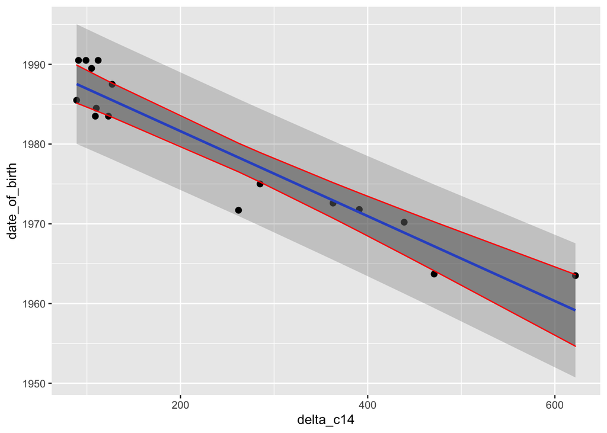

```r
# Plot with data, fit, fit interval, and prediction interval
ggplot(data = nuclear,
       mapping = aes(x = delta_c14,
                     y = date_of_birth)) +
  # prediction intervals-- predicting new values--  if we picked a new value 95% of the time, it should fall in this range
  geom_ribbon(mapping = aes(ymin = lwr_pi,
                            ymax = upr_pi),
              alpha = 0.2) +
  # model fit
  geom_point(color = "black", size = 2) +
  stat_smooth(method = lm) +
  # fit interval -- just coefficient error (precision)
  geom_ribbon(mapping = aes(ymin = lwr_ci,
                            ymax = upr_ci),
              color = "red",
              alpha = 0.3)
```

###### The data points are in black, the regression line is in blue, the red lines are the fit interval, and the lighter gray is the prediction interval.